# M2.891_20241_PEC4-Enunciado_actualizado

[figure not shown]

M2.891 · Aprendizaje automático · PEC4

2024-1 · Máster universitario en Ciencia de datos (Data science)

Estudios de Informática, Multimedia y Telecomunicación

# **PEC 4: Aprendizaje con Ensemble Avanzado, Transfer Learning y Evaluación de Modelos**

## **Objetivo:**

El objetivo principal de esta cuarta PEC es consolidar los conocimientos adquiridos en las PECs anteriores e introducir técnicas avanzadas de ensemble y transfer learning. Esta práctica le ayudará a entender cómo combinar varios modelos y aplicar aprendizaje profundo preentrenado para mejorar el rendimiento, evaluándolos críticamente con métricas adecuadas. Nos centraremos en métricas como la sensibilidad y la especificidad, especialmente importantes en el contexto médico.

## **Contexto:**

Después de completar las PECs anteriores (PAC 1, PAC 2 y PAC 3), ya está familiarizado con la preparación de datos, el aprendizaje supervisado y no supervisado, la reducción de dimensionalidad y el manejo de conjuntos de datos desbalanceados. En esta PAC 4, aplicará estas habilidades utilizando técnicas avanzadas como Bagging, Boosting, Stacking, Cascading y Transfer Learning con un modelo preentrenado adaptado para datos tabulares.

### **Conjunto de Datos:**

Trabajará con un conjunto de datos real sobre diabetes. Estos datos contienen varias variables clínicas que permiten predecir si un paciente tiene diabetes. Su primer paso será preparar los datos y realizar un análisis exploratorio. A continuación, comparará dos enfoques:

1. Utilizar las variables originales como descriptores.
2. Utilizar los principales componentes (PCs) obtenidos del Análisis de Componentes Principales (PCA) como descriptores.

Además, aplicará **Transfer Learning** utilizando un modelo de red neuronal preentrenado para mejorar el rendimiento de su mejor modelo.

## **Resumen de las Tareas:**

### **1. Preparación de Datos y Análisis Exploratorio (EDA) (0.5 puntos)**

- Cargue el conjunto de datos sobre diabetes.
- Realice un análisis estadístico básico.
- Realice un análisis exploratorio de datos (EDA) con visualizaciones para entender la distribución y correlación.
- Limpie y preprocesamente los datos, incluyendo el tratamiento de valores perdidos y valores atípicos.

### **2. Reducción de Dimensionalidad (1 punto)**

- Preparación: Se separan a los pacientes diabéticos para el entrenamiento del PCA. Divide los datos diabéticos en entrenamiento/validación (80%) y pruebas (20%), random state=42.
- Normalización y construcción del modelo PCA: Se normalizan los datos y se crea el modelo de los componentes principales con el conjunto de pacientes de entrenamiento del paso anterior (diabéticos)
- Proyección de los Datos Restantes: Utilizamos el modelo creado en el paso anterior para proyectar tanto los datos de test de los pacientes diabéticos como los datos de los pacientes no diabéticos.
- Creación del Conjunto de Entrenamiento para Clasificación: El conjunto de datos proyectado se utiliza como entrada para los modelos de clasificación.

### **3. Entrenamiento y Evaluación de Modelos Base (2.5 puntos)**

- Entrene modelos base con las variables originales como descriptores.
- Entrene modelos base con los componentes principales (PCs) como descriptores.
- Evalúe los modelos utilizando métricas de exactitud, sensibilidad, especificidad, ROC-AUC y análisis de la matriz de confusión.

### **4. Técnicas Avanzadas de Ensemble (3 puntos)**

- Implemente y evalúe técnicas de ensemble como Bagging, Boosting, Stacking y Cascading utilizando las variables originales.
- Repita la implementación con los componentes principales como descriptores.
- Compare el rendimiento de cada método y analice los resultados.

### **5. Convolutional Neural Network para Datos Tabulares (1 punto + 1 punto adicional)**

- Diseña un modelo Convolutional Neural Network (CNN) para datos tabulares.
- Entrene el modelo utilizando los datos preprocesados y compare el rendimiento con los métodos de ensemble.
- Evalúe el modelo utilizando exactitud, sensibilidad, especificidad, ROC-AUC y matriz de confusión.
- Adapte, entrene y evalúe un modelo de red neuronal preentrenado (ResNet50) para datos tabulares (opcional, 1 punto extra).

### **6. Optimización del Modelo y Sintonización de Hiperparámetros (2 puntos)**

- Realice una sintonización de hiperparámetros con GridSearchCV para el mejor modelo de ensemble.
- Evalúe el modelo optimizado en el conjunto de test.

### **Importante:**

- La entrega debe ser en formato Jupyter Notebook (*.ipynb) y HTML.
- No utilice métodos o funciones declarados "deprecated".
- Incluya su nombre y apellidos en la solución.
- Utilice celdas Markdown para responder a las preguntas teóricas.

Esta PAC está diseñada para desafiar su comprensión sobre técnicas de ensemble avanzadas y transfer learning, ofreciendo una visión completa de cómo mejorar el rendimiento de los modelos en contextos médicos. Al final de esta PAC, será capaz de:

- Aplicar técnicas avanzadas para mejorar el rendimiento de los modelos de clasificación.
- Utilizar transfer learning para aumentar la eficiencia de los modelos en datos tabulares.
- Evaluar los modelos utilizando métricas relevantes en el contexto médico, con énfasis en sensibilidad y especificidad.

**Nombre y apellidos: Víctor M. Sola Rodríguez**

Para la realización de la práctica, necesitaremos importar los siguientes módulos:

```python
# Upgrade pip to ensure compatibility
!pip install --upgrade pip --quiet
# Keep active

# Install required libraries with quiet output
!pip install scikit-learn tensorflow keras-tuner --quiet
!pip install --upgrade scikit-learn
# Keep active
!pip install numpy pandas seaborn matplotlib tensorflow keras_tuner imbalanced-learn
import numpy as np
import pandas as pd
import seaborn as sns
import matplotlib.pyplot as plt
import tensorflow as tf
import keras_tuner as kt
from mpl_toolkits.mplot3d import Axes3D
from sklearn.model_selection import train_test_split, GridSearchCV
from sklearn.model_selection import KFold
from sklearn.preprocessing import StandardScaler
from sklearn.decomposition import PCA
from sklearn.ensemble import BaggingClassifier, AdaBoostClassifier, StackingClassifier
from sklearn.ensemble import RandomForestClassifier # Import RandomForestClassifier
from sklearn.svm import SVC
from sklearn.tree import DecisionTreeClassifier
from sklearn.linear_model import LogisticRegression
from sklearn.metrics import roc_curve, accuracy_score, confusion_matrix, roc_auc_score, RocCurveDisplay, classification_report
from sklearn.metrics import make_scorer, accuracy_score, recall_score
from sklearn.base import BaseEstimator, ClassifierMixin
from imblearn.over_sampling import SMOTE, ADASYN
from tensorflow.keras.layers import Dense, Input, Dropout, Flatten
from tensorflow.keras.models import Model
from tensorflow.keras.applications import ResNet50
from tensorflow.keras.utils import to_categorical
from tensorflow.keras.models import Sequential
from tensorflow.keras.layers import Conv2D, MaxPooling2D, BatchNormalization, GlobalAveragePooling2D
from tensorflow.keras.models import Sequential
from tensorflow.keras.optimizers import Adam
from keras_tuner.tuners import RandomSearch
from keras.models import Sequential
from keras.layers import Dense, Dropout, Conv2D, Flatten, BatchNormalization, MaxPooling2D
from keras.optimizers import Adam

# Ensure that plots are displayed inline (especially useful for Jupyter Notebooks and Colab)
%matplotlib inline
```

### ¿Por qué utilizar Google Colab para esta PEC 4?

Teniendo en cuenta los requisitos de esta PEC 4, que incluyen **cálculos intensivos**, **modelos preentrenados** y la necesidad de **resultados consistentes y reproducibles**, Google Colab ofrece una plataforma robusta, eficiente y accesible. Entre sus principales ventajas destacan:

1. **Acceso a Hardware Potente (GPU/TPU gratuitas):**  
   Google Colab ofrece acceso gratuito a GPUs y TPUs, lo que resulta especialmente útil para entrenar modelos complejos, especialmente al implementar el **transfer learning**. El uso de una GPU puede reducir significativamente el tiempo de entrenamiento de los modelos, acelerando el proceso de experimentación.
2. **Sin Necesidad de Configuración Local:**  
   Se puede evitar la complejidad de configurar el entorno local con todas las dependencias necesarias. Colab viene preconfigurado con las versiones más recientes de bibliotecas esenciales de Python como **Scikit-Learn, TensorFlow, PyTorch**, y otras que se utilizan en esta PEC. Esto reduce los problemas de compatibilidad y asegura una ejecución fluida del notebook.
3. **Integración Sencilla con Google Drive:**  
   Colab permite una integración directa con Google Drive, facilitando la tarea de guardar los progresos, conjuntos de datos y modelos sin preocuparse por las limitaciones de almacenamiento local. Esta característica es especialmente útil cuando se trabaja con conjuntos de datos grandes, como el conjunto de datos de diabetes utilizado en esta PEC.
4. **Acceso a Modelos Preentrenados:**  
   Cuando se aplica **transfer learning**, a menudo es necesario descargar grandes modelos preentrenados (como ResNet, VGG). Colab tiene una conexión a internet rápida, lo que facilita el acceso y la carga de estos modelos de manera más rápida que en un entorno local típico.
5. **Reproducibilidad y Consistencia:**  
   Utilizar un entorno en la nube como Colab asegura una ejecución consistente para todos, ya que se emplea la misma configuración. Esto reduce la variabilidad en los resultados debido a diferencias en el hardware o en la configuración del software.

**Implementación:** Abre Colab, permite que acceda a Google Drive y crea un directorio de trabajo:

```python
from google.colab import drive
drive.mount('/content/drive')
```

```python
import os

# Creamos ruta del directorio
ruta_dir = '/content/drive/My Drive/APR_AUT_PR4'

# Creamos directorio
os.makedirs(ruta_dir,exist_ok=True)
```

### **1. Preparación de Datos y Análisis Exploratorio (EDA) (0.5 puntos)**

- 1.1. Cargad el conjunto de datos sobre diabetes.

**Implementación:** carga el archivo en un dataframe. Verifica los tipos de variables.

```python
ruta_csv = '/content/drive/My Drive/APR_AUT_PR4/diabetes.csv'
df = pd.read_csv(ruta_csv)
#print(df.head())
print(df.dtypes)
```

```
Pregnancies                   int64
Glucose                       int64
BloodPressure                 int64
SkinThickness                 int64
Insulin                       int64
BMI                         float64
DiabetesPedigreeFunction    float64
Age                           int64
Outcome                       int64
dtype: object
```

- 1.2. Análisis estadístico básico.

**Implementación:** Realiza el análisis estadístico básico.

```
count    768.000000
mean       3.845052
std        3.369578
min        0.000000
25%        1.000000
50%        3.000000
75%        6.000000
max       17.000000
Name: Pregnancies, dtype: float64
```

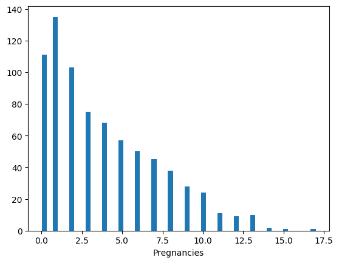

```
count    768.000000
mean     120.894531
std       31.972618
min        0.000000
25%       99.000000
50%      117.000000
75%      140.250000
max      199.000000
Name: Glucose, dtype: float64
```

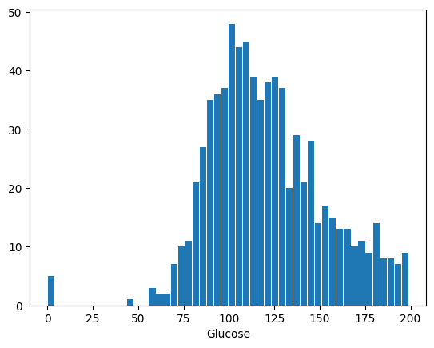

```
count    768.000000
mean      69.105469
std       19.355807
min        0.000000
25%       62.000000
50%       72.000000
75%       80.000000
max      122.000000
Name: BloodPressure, dtype: float64
```

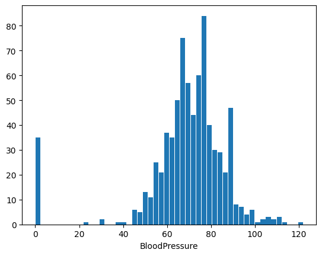

```
count    768.000000
mean      20.536458
std       15.952218
min        0.000000
25%        0.000000
50%       23.000000
75%       32.000000
max       99.000000
Name: SkinThickness, dtype: float64
```

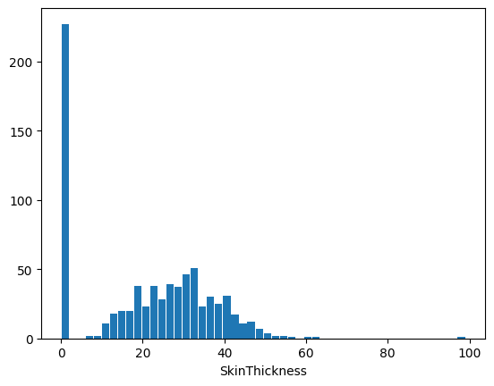

```
count    768.000000
mean      79.799479
std      115.244002
min        0.000000
25%        0.000000
50%       30.500000
75%      127.250000
max      846.000000
Name: Insulin, dtype: float64
```

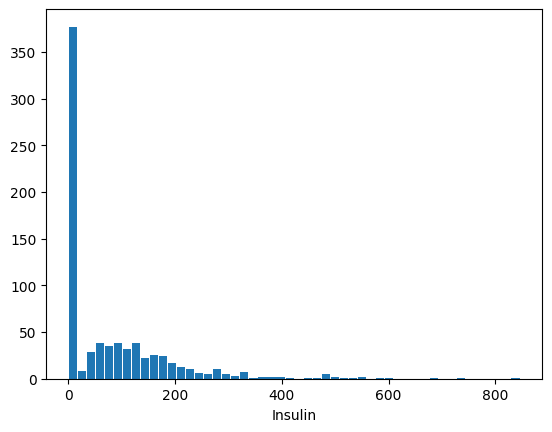

```
count    768.000000
mean      31.992578
std        7.884160
min        0.000000
25%       27.300000
50%       32.000000
75%       36.600000
max       67.100000
Name: BMI, dtype: float64
```

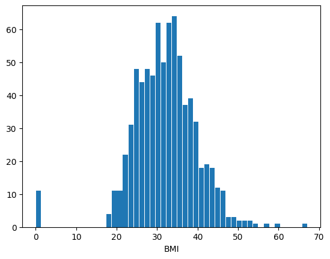

```
count    768.000000
mean       0.471876
std        0.331329
min        0.078000
25%        0.243750
50%        0.372500
75%        0.626250
max        2.420000
Name: DiabetesPedigreeFunction, dtype: float64
```

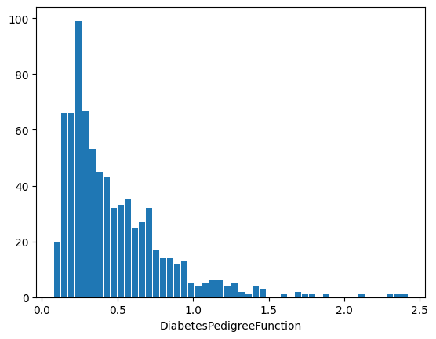

```
count    768.000000
mean      33.240885
std       11.760232
min       21.000000
25%       24.000000
50%       29.000000
75%       41.000000
max       81.000000
Name: Age, dtype: float64
```

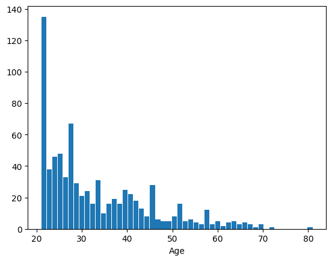

```
count    768.000000
mean       0.348958
std        0.476951
min        0.000000
25%        0.000000
50%        0.000000
75%        1.000000
max        1.000000
Name: Outcome, dtype: float64
```

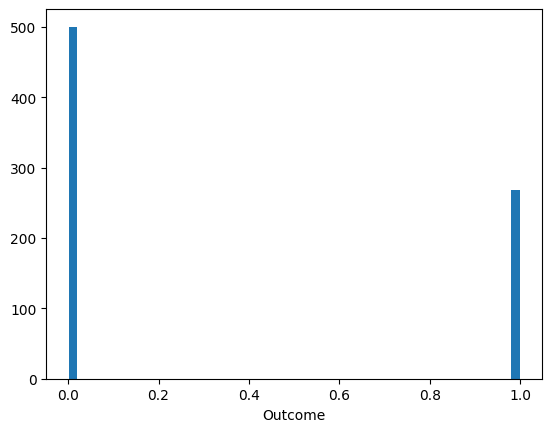

```python
variables_num = df.select_dtypes(include = ['number']).columns

for var in variables_num:
    desc = df[var].describe()
    print(desc)
    plt.hist(df[var], bins=50, rwidth=0.9)
    plt.xlabel(var)
    plt.show()
```

- 1.3. Realizad un análisis exploratorio de datos (EDA) con visualizaciones para entender la distribución y correlación.  
  1.3.1. Análisis de Variables Categóricas

En principio hemos visto con dtype que todas las variables son numéricas pero realmente podemos entender la variable Outcome como categórica ya que determina si tiene diabetes o no (si/no).

Por lo tanto la hemos tratado como tal para estudiar su frecuencia.

```
FRECUENCIAS (X):

Outcome
0    500
1    268
Name: count, dtype: int64
```

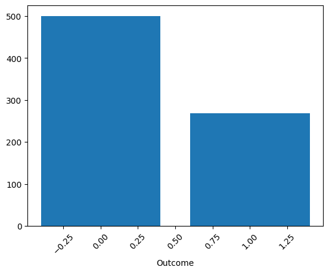

```python
#VARIABLES CATEGÓRICAS
var_categorica = df['Outcome'].astype('category')

print('\nFRECUENCIAS (X):\n')
frec = var_categorica.value_counts()
print(frec)
plt.bar(frec.index, frec.values)
plt.xticks(rotation=45)
plt.xlabel(var)
plt.show()
```

1.3.2. Análisis de Variables Numéricas

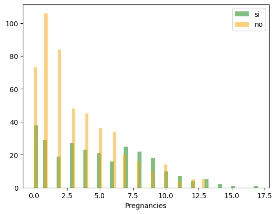

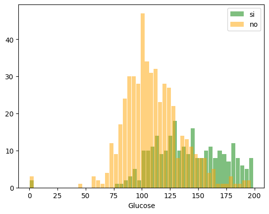

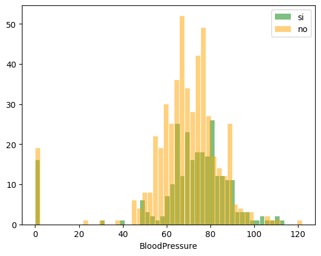

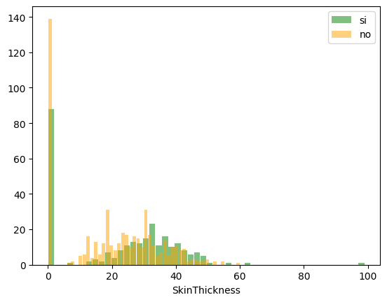

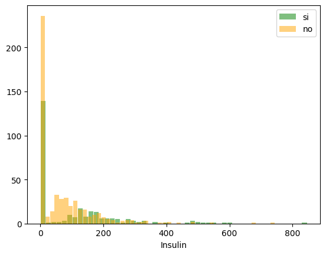

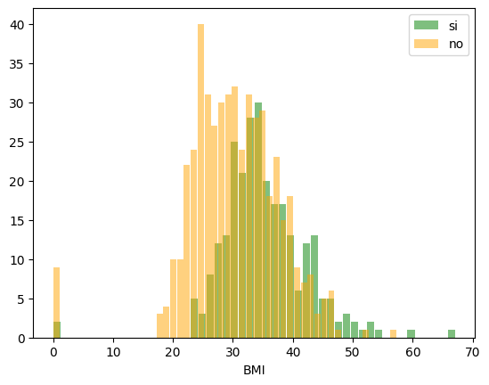

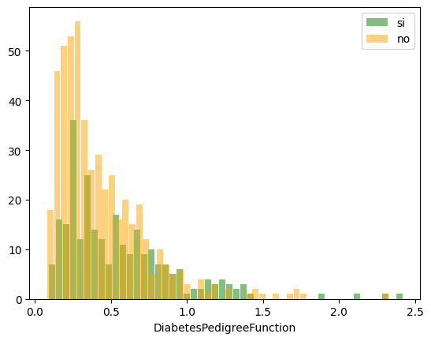

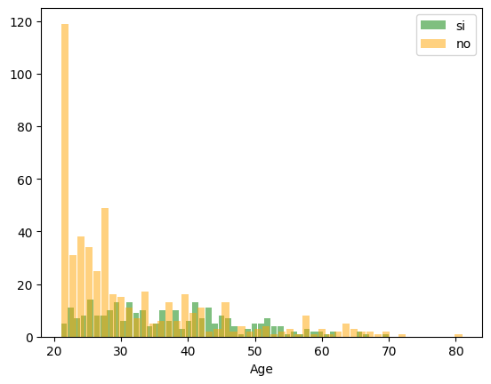

```python
#VARIABLES NUMÉRICAS
si = df[df['Outcome'] == 1]
no = df[df['Outcome'] == 0]

var_numericas_col = df.select_dtypes(include=['number']).columns.drop('Outcome')

for var in var_numericas_col:
    desc_si = si[var]
    desc_no = no[var]
    plt.hist(desc_si, alpha = 0.5, bins=50, rwidth=0.9, color = 'green', label = 'si')
    plt.hist(desc_no, alpha = 0.5, bins=50, rwidth=0.9, color = 'orange', label = 'no')
    plt.xlabel(var)
    plt.legend()
    plt.show()
```

1.3.3. Matriz de Correlación

```python
# Filtramos dejando solamente las correlaciones más altas.
var_numericas = df.select_dtypes(include=['number'])
correlaciones = var_numericas.corr()
correlaciones_top = correlaciones[abs(correlaciones)>0.3]
print(correlaciones_top)
```

```
                          Pregnancies   Glucose  BloodPressure  SkinThickness  \
Pregnancies                  1.000000       NaN            NaN            NaN
Glucose                           NaN  1.000000            NaN            NaN
BloodPressure                     NaN       NaN            1.0            NaN
SkinThickness                     NaN       NaN            NaN       1.000000
Insulin                           NaN  0.331357            NaN       0.436783
BMI                               NaN       NaN            NaN       0.392573
DiabetesPedigreeFunction          NaN       NaN            NaN            NaN
Age                          0.544341       NaN            NaN            NaN
Outcome                           NaN  0.466581            NaN            NaN

                           Insulin       BMI  DiabetesPedigreeFunction  \
Pregnancies                    NaN       NaN                       NaN
Glucose                   0.331357       NaN                       NaN
BloodPressure                  NaN       NaN                       NaN
SkinThickness             0.436783  0.392573                       NaN
Insulin                   1.000000       NaN                       NaN
BMI                            NaN  1.000000                       NaN
DiabetesPedigreeFunction       NaN       NaN                       1.0
Age                            NaN       NaN                       NaN
Outcome                        NaN       NaN                       NaN

                               Age   Outcome
Pregnancies               0.544341       NaN
Glucose                        NaN  0.466581
BloodPressure                  NaN       NaN
SkinThickness                  NaN       NaN
Insulin                        NaN       NaN
BMI                            NaN       NaN
DiabetesPedigreeFunction       NaN       NaN
Age                       1.000000       NaN
Outcome                        NaN  1.000000
```

- 1.4. Preprocesamiento de datos:

**Implementación:** Limpia y preprocesa los datos, incluyendo el tratamiento de valores perdidos y valores atípicos.

```python
# Obtenemos valores perdidos
print(df.isnull().sum())

# Imputamos por la mediana los valores = 0 de los atributos que no tienen sentido que valgan 0
col_imputadas = ['Glucose','BloodPressure','SkinThickness','Insulin','BMI']
for col in col_imputadas:
    df[col] = df[col].replace(0, df[col].median())
```

```
Pregnancies                 0
Glucose                     0
BloodPressure               0
SkinThickness               0
Insulin                     0
BMI                         0
DiabetesPedigreeFunction    0
Age                         0
Outcome                     0
dtype: int64
```

En este caso no hay valores perdidos. Por otro lado, imputamos por la mediana los valores = 0 de los atributos que no tienen sentido que valgan 0. En cuanto a los valores máximos entendemos que son factibles.

- 1.5. Balanceo de clases

**Implementación:** Verificación de la distribución de clases.

```python
print(df['Outcome'].value_counts())
```

```
Outcome
0    500
1    268
Name: count, dtype: int64
```

Dado que tenemos previsto utilizar redes neuronales y transferencia de aprendizaje o transfer learning (que puede gestionar bien grandes conjuntos de datos), el mejor método sería una combinación de **SMOTE** y **ADASYN**:

- Primero utiliza **SMOTE**. Ayudará a crear un conjunto de datos equilibrado con muestras sintéticas (random_state=42).
- Después **ADASYN**. Perfeccionará aún más los datos sintéticos, centrándose en las muestras desafiantes (random_state=42).

**Implementación:** Realiza el análisis de balance de clases.

```python
X = df.drop('Outcome', axis=1)
y = df['Outcome']

# SMOTE
smote_os = SMOTE(random_state=42)
X_smote, y_smote = smote_os.fit_resample(X,y)

# ADASYN
adasyn_os = ADASYN(random_state=42)
X_adasyn, y_adasyn = adasyn_os.fit_resample(X_smote, y_smote)
```

**Implementación:** Crea un nuevo DataFrame para los datos remuestreados.

```python
df_rem = pd.DataFrame(X_adasyn, columns=X.columns)
df_rem['Outcome'] = y_adasyn
df_rem.head()
```

|  | Pregnancies | Glucose | BloodPressure | SkinThickness | Insulin | BMI | DiabetesPedigreeFunction | Age | Outcome |
| --- | --- | --- | --- | --- | --- | --- | --- | --- | --- |
| 0 | 6 | 148 | 72 | 35 | 30.5 | 33.6 | 0.627 | 50 | 1 |
| 1 | 1 | 85 | 66 | 29 | 30.5 | 26.6 | 0.351 | 31 | 0 |
| 2 | 8 | 183 | 64 | 23 | 30.5 | 23.3 | 0.672 | 32 | 1 |
| 3 | 1 | 89 | 66 | 23 | 94.0 | 28.1 | 0.167 | 21 | 0 |
| 4 | 0 | 137 | 40 | 35 | 168.0 | 43.1 | 2.288 | 33 | 1 |

### **2. Reducción de Dimensionalidad (1 punto)**

En esta parte de la PEC, utilizaremos **Análisis de Componentes Principales (PCA)** para mejorar la información de los pacientes diabéticos con el objetivo de facilitar la separación en el modelo de clasificación. Nuestro objetivo es garantizar que el modelo PCA capture patrones útiles para distinguir mejor a los pacientes diabéticos de los no diabéticos.

**Riesgos de Overfitting y Cómo Evitarlos:**

Cuando construimos el modelo PCA solo con pacientes diabéticos, puede existir el riesgo de que los componentes principales capturen patrones específicos de este grupo y no se generalicen bien para los pacientes no diabéticos. Para mitigar este riesgo, seguiremos un enfoque robusto con **validación cruzada**, el cual:

1. **Reduce el sobreajuste**, evaluando la estabilidad de los componentes principales a través de diferentes particiones de datos de pacientes diabéticos.
2. **Garantiza una mejor generalización**, ya que seleccionamos un conjunto estable de componentes mediante la **promediación de las cargas** de los componentes principales a través de los diferentes pliegues (folds) de la validación cruzada.

### **Proceso Recomendado**

1. **Preparación:** Se separan los pacientes diabéticos para el entrenamiento del PCA. Divide los datos diabéticos en entrenamiento/validación (80%) y pruebas (20%), random_state=42.
2. **Normalización y Validación Cruzada para el PCA:** Utilizamos validación cruzada (n_splits=5, shuffle=True, random_state=42) para normalizar los datos y evaluar la consistencia de los componentes principales.
3. **Promediación de los Componentes Principales:** Se promedian las cargas de los componentes principales para obtener un conjunto estable.
4. **Proyección de los Datos Restantes:** Utilizamos los componentes estables para proyectar tanto los datos de test de los pacientes diabéticos como los datos de los pacientes no diabéticos.
5. **Creación del Conjunto de Entrenamiento para Clasificación:** El conjunto de datos proyectado se utiliza como entrada para los modelos de clasificación.

Este enfoque garantiza que el modelo PCA no sobreajuste a los pacientes diabéticos utilizados para construirlo, y nos permite utilizar descriptores coherentes para todo el conjunto de datos. Esto mejora la robustez del modelo de clasificación, minimizando el riesgo de sesgo y mejorando la separación de los pacientes en base a sus características proyectadas.

- 2.1. Preparación.

**Implementación:** Se separan los pacientes diabéticos para el entrenamiento del PCA. Divide los datos diabéticos en entrenamiento/validación (80%) y pruebas (20%), random state=42.

```python
df_diabeticos = df_rem[df_rem['Outcome']==1]

X_diabeticos = df_diabeticos.drop('Outcome', axis=1)
y_diabeticos = df_diabeticos['Outcome']

X_train, X_test, y_train, y_test = train_test_split(X_diabeticos, y_diabeticos, test_size=0.2, random_state=42, stratify=y_diabeticos)
```

- 2.2. Normalización y construcción del modelo PCA

**Implementación:** Se normalizan los datos y se crea el modelo de los componentes principales con el conjunto de pacientes de entrenamiento del paso anterior (diabéticos) con el 95% de varianza retenida.

```python
from sklearn.model_selection import StratifiedKFold

# Aplicamos validación curzada para el PCA
k = 5

skf = StratifiedKFold(n_splits=k, shuffle=True, random_state=42)

accuracy = []
f1 = []
roc = []
componentes_PCA = []

for fold, (train_id, val_id) in enumerate(skf.split(X_train, y_train)):

    # Separamos datos de entrenamiento y validación
    X_train_fold = X_train.iloc[train_id]
    y_train_fold = y_train.iloc[train_id]
    X_val_fold = X_train.iloc[val_id]
    y_val_fold = y_train.iloc[val_id]

    # Normalizamos
    scaler = StandardScaler()
    X_train_scaled = scaler.fit_transform(X_train_fold)
    X_val_scaled = scaler.transform(X_val_fold)

    # Aplicamos PCA (95% varianza)
    pca = PCA(n_components=0.95, random_state=42)
    X_train_pca = pca.fit_transform(X_train_scaled)
    X_val_pca = pca.transform(X_val_scaled)

    # Guardamos los componentes para poder hacer la promediación
    componentes_PCA.append(pca.components_)


# Fuentes:
# Prácticas anteriores
# https://www.datacamp.com/tutorial/principal-component-analysis-in-python
# https://stackoverflow.com/questions/15851869/principal-component-analysis-pca-compute-mean-using-python
```

Al intentar hacer el promedio da error debido a que las matrices son de diferente tamaño. Por lo que rellenaremos las más pequeñas para poder hacer el promedio.

```python
# Comprobamos dimensiones de las matrices
for i in range(len(componentes_PCA)):
  print(componentes_PCA[i].shape)
```

```
(8, 8)
(7, 8)
(7, 8)
(8, 8)
(8, 8)
```

```python
# Rellenamos las matrices 2 y 3
max_filas = 8

for i in [1, 2]:
    matriz = componentes_PCA[i]
    n_filas, n_cols = matriz.shape

    if n_filas < max_filas:
      nueva_matriz = np.zeros((max_filas, n_cols))
      nueva_matriz[:n_filas, :] = matriz
      componentes_PCA[i] = nueva_matriz

for i in range(len(componentes_PCA)):
  print(componentes_PCA[i].shape)
```

```
(8, 8)
(8, 8)
(8, 8)
(8, 8)
(8, 8)
```

```python
promedio_componentes = np.mean(componentes_PCA, axis=0)
print(promedio_componentes)
```

```
[[-0.39520341  0.20704827 -0.08665847  0.48400061  0.31131761  0.42633381
   0.35506485 -0.37878733]
 [ 0.35430759  0.40010856  0.50944038  0.24432214  0.26384079  0.20930899
   0.02438714  0.51842354]
 [-0.0536326   0.44749814 -0.39174804 -0.18643479  0.57100391 -0.49951637
   0.01308221  0.07509803]
 [ 0.11164854 -0.05375963 -0.0425784  -0.01063824 -0.01311841  0.00653867
   0.24995643  0.04318769]
 [-0.13003197  0.23000754  0.2169419  -0.32888923 -0.29780301 -0.18895553
   0.74394109  0.03886681]
 [-0.18773971 -0.29227753  0.33142762  0.04662071  0.26063748 -0.20339171
  -0.02929238 -0.01602367]
 [-0.40104442 -0.08083694 -0.07675711  0.34141616 -0.1820765  -0.22312424
   0.03416279  0.43758004]
 [-0.11136919 -0.06719269 -0.03094693 -0.04712531  0.04934694  0.0820237
  -0.01702183  0.12513653]]
```

**Implementación:** Realice las gráficas que considere necesarias.

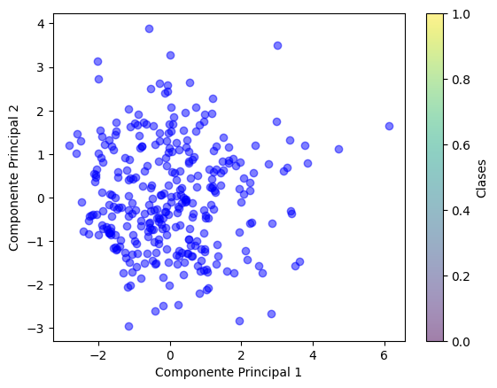

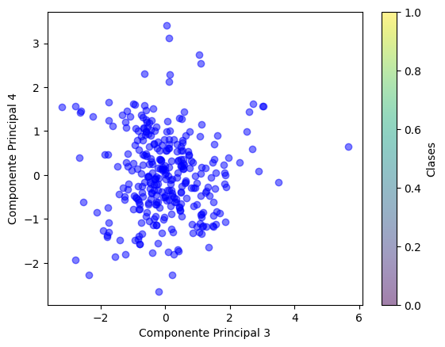

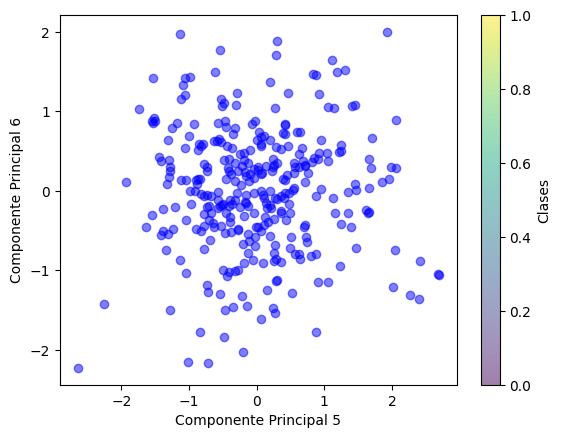

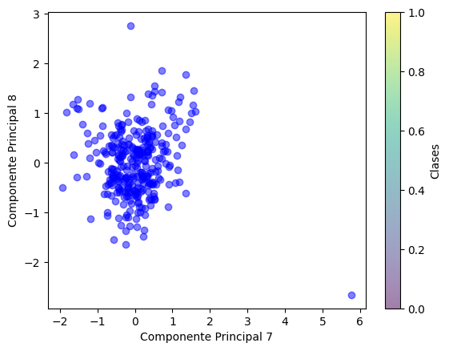

```python
# Representamos las 8 componentes
plt.scatter(X_train_pca[:, 0], X_train_pca[:, 1], c='blue', cmap='viridis', alpha=0.5)
plt.xlabel('Componente Principal 1')
plt.ylabel('Componente Principal 2')
plt.colorbar(label='Clases')
plt.show()

plt.scatter(X_train_pca[:, 2], X_train_pca[:, 3], c='blue', cmap='viridis', alpha=0.5)
plt.xlabel('Componente Principal 3')
plt.ylabel('Componente Principal 4')
plt.colorbar(label='Clases')
plt.show()

plt.scatter(X_train_pca[:, 4], X_train_pca[:, 5], c='blue', cmap='viridis', alpha=0.5)
plt.xlabel('Componente Principal 5')
plt.ylabel('Componente Principal 6')
plt.colorbar(label='Clases')
plt.show()

plt.scatter(X_train_pca[:, 6], X_train_pca[:, 7], c='blue', cmap='viridis', alpha=0.5)
plt.xlabel('Componente Principal 7')
plt.ylabel('Componente Principal 8')
plt.colorbar(label='Clases')
plt.show()
```

- 2.3. Proyección de los Datos Restantes

En este punto, ya hemos construido el modelo PCA utilizando solo los datos de los pacientes diagnosticados con diabetes. Ahora, para poder comparar el rendimiento de nuestros clasificadores de manera consistente, necesitamos proyectar **todas** las muestras. Tanto los datos escalados de los pacientes con diabetes (restante 20%) como los de los pacientes sin diabetes, sobre este mismo modelo PCA.

##### **¿Por qué proyectar todos los datos sobre el mismo modelo PCA?**

1. **Consistencia de los descriptores**:
   - Al proyectar todos los datos sobre el mismo modelo PCA, obtenemos un conjunto de descriptores uniformes (los componentes principales) para todos los pacientes, independientemente de su diagnóstico. Esto es clave para que los clasificadores trabajen con las mismas variables de entrada.
2. **Reducción de la dimensionalidad**:
   - Utilizar los componentes principales como variables de entrada reduce el número de dimensiones, lo que facilita el entrenamiento de los modelos y reduce el riesgo de overfitting.
3. **Mejora de la generalización**:
   - Al usar descriptores PCA, que son las combinaciones lineales de las variables originales más informativas, se mejora la capacidad del modelo para generalizar a nuevos datos.

**Implementación:** Utilizamos el modelo creado en el paso anterior para proyectar tanto los datos de test de los pacientes diabéticos (20% restante) como los datos de los pacientes no diabéticos.

```python
# Datos de test pacientes diabéticos
X_test_diab = X_test

# Datos de pacientes no diabeticos
df_no_diabeticos = df_rem[df_rem['Outcome']==0]
X_no_diab = df_no_diabeticos.drop('Outcome', axis=1)

# Ecalamos
X_test_diab_scaled = scaler.transform(X_test_diab)
X_no_diab_scaled = scaler.transform(X_no_diab)

X_test_diab_pca = pca.transform(X_test_diab_scaled)
X_no_diab_pca = pca.transform(X_no_diab_scaled)
```

**Implementación:** Realice las gráficas que considere necesarias. Ayuda: Realice la gráfica en 2D de las dos primeras componentes principales (o 3D para las tres primeras). Incluye los datos utilizados para entrenar el modelo (diabéticos 80%), el 20% restante de diabéticos y los no diabéticos. Utilice colores distintos para cada grupo.

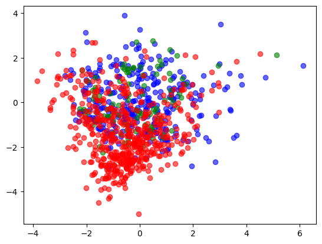

```python
# Diabéticos
plt.scatter(
    X_train_pca[:, 0],
    X_train_pca[:, 1],
    c='blue',
    label='Diabéticos (train)',
    alpha=0.6
)

plt.scatter(
    X_test_diab_pca[:, 0],
    X_test_diab_pca[:, 1],
    c='green',
    label='Diabéticos (test)',
    alpha=0.6
)

# No diabéticos
plt.scatter(
    X_no_diab_pca[:, 0],
    X_no_diab_pca[:, 1],
    c='red',
    label='No diabéticos',
    alpha=0.6
)
```

- 2.4. Creación del Conjunto de Entrenamiento para Clasificación

Al trabajar con modelos de PCA utilizando la librería `scikit-learn`, es importante entender que el objeto del PCA (`pca_final`) **no guarda automáticamente los componentes principales asociados a las muestras transformadas**. El PCA solo mantiene los componentes del modelo (es decir, las combinaciones lineales de las variables originales) y la información de la varianza explicada.

Por ello, si deseáis conservar los **valores de los componentes principales (scores)** asociados a cada muestra transformada para su uso futuro, debéis hacerlo **manualmente**, creando un DataFrame separado. Esto os permitirá:

1. **Reutilizar los datos**: Podréis cargarlos directamente en el futuro sin tener que repetir el cálculo del PCA.
2. **Asegurar la consistencia**: Evitad diferencias si el conjunto de datos original cambia o si se añaden nuevas muestras.
3. **Preparar los datos para el análisis**: Podéis combinar los scores con otras variables o utilizarlos directamente en modelos de clasificación.

Consideraciones finales:

- Recordad que este proceso debe repetirse para cualquier conjunto de datos que deseéis proyectar en el modelo PCA (diabetic_test_data, non_diabetic_data).
- Esta separación permite mantener el modelo PCA enfocado únicamente en transformaciones y conservar los scores como datos procesados.

Esta particularidad puede parecer poco intuitiva al principio, pero asegura que el modelo se mantenga modular y fácil de utilizar para otras transformaciones.

El conjunto de datos resultante contiene:

1. Una columna para cada componente principal ("PC1", "PC2", ..., "PCn").
2. Una columna "Outcome" para identificar si son muestras de diabéticos o no.

```python
columnas = ["PC1", "PC2", "PC3","PC4", "PC5", "PC6","PC7", "PC8"]

# Diabéticos (train)
df_train_diabeticos = pd.DataFrame(X_train_pca, columns=columnas)
df_train_diabeticos["Outcome"] = 1

# Diabéticos (test)
df_test_diabeticos = pd.DataFrame(X_test_diab_pca, columns=columnas)
df_test_diabeticos["Outcome"] = 1

# No diabéticos
df_no_diabeticos = pd.DataFrame(X_no_diab_pca, columns=columnas)
df_no_diabeticos["Outcome"] = 0

# Combinamos los 3 dataframes
df_combi = pd.concat([df_train_diabeticos, df_test_diabeticos, df_no_diabeticos], ignore_index=True)
print(df_combi.head())
```

```
        PC1       PC2       PC3       PC4       PC5       PC6       PC7  \
0  2.295393 -0.570816  0.047694 -0.574117 -1.408416  0.377300  0.088886
1  4.719627  1.114350 -2.656123  0.392108  1.471963 -0.715492  0.339195
2 -0.007459 -2.022148 -0.254013  0.601623  0.668197  0.539192 -0.361228
3 -1.018237  0.420743 -0.094794  0.183820  1.350101 -0.275182 -1.185700
4 -0.248456 -0.605495  1.116778 -1.336972  0.472882 -0.028725 -0.399517

        PC8  Outcome
0  0.265902        1
1 -0.443541        1
2  0.660558        1
3 -1.123023        1
4 -0.259326        1
```

### 3. Entrenamiento y Evaluación de Modelos Base (2.5 puntos)

Se formarán cuatro modelos diferentes:

- 1. Regresión Logística
- 2. Árbol de Decisión
- 3. Bosque Aleatorio (Random Forest)
- 4. SVM

y cada modelo será entrenado utilizando los dos grupos de:

- Las características originales
- Las características transformadas de PCA.

##### 3.1 Entrenamiento

3.1.1. Características originales

Pasos a seguir para las entradas de las características originales:

- 1. Reúne las características originales en un solo dataframe llamado X y otro llamado y para la salida u outcome.
- 2. Asigna las etiquetas de clase: Asigna 1 para muestras diabéticas y 0 para muestras no diabéticas.
- 3. Divide los datos: Asegúrate de dividir el conjunto de datos combinado en conjuntos de entrenamiento (80%) y prueba si no lo has hecho ya. Esto evita la fuga de información de las pruebas al entrenamiento.
- 4. Entrenamiento y evaluación de modelos de clasificación: Utiliza el conjunto de datos para entrenar modelos que puedan separar las clases diabéticas y no diabéticas.

**Implementación:** Para las características originales, prepara la entrada X y salida/outcome y para los clasificadores. Divide el conjunto de datos en 80%-20% para entrenamiento y prueba.

```python
# Seleccionamos datos originales
X = df.drop('Outcome', axis=1)
y = df['Outcome']

# Dividimos datos en train y test
X_train, X_test, y_train, y_test = train_test_split(X, y, test_size=0.2, random_state=42, stratify=y)
```

```python
# Regresión logística
regresion_log = LogisticRegression(random_state=42, max_iter=500)
regresion_log.fit(X_train, y_train)

y_pred = regresion_log.predict(X_test)

# EVALUACIÓN

# Exactitud
# TRAIN
y_train_rl = regresion_log.predict(X_train)
acc_train_rl_ori = accuracy_score(y_train,y_train_rl)

# TEST
y_test_rl = regresion_log.predict(X_test)
acc_test_rl_ori = accuracy_score(y_test,y_test_rl)

# Matriz de confusion
mc_rl_ori = confusion_matrix(y_test, y_pred)

# Sensibilidad
sensibilidad_rl_ori = recall_score(y_test, y_pred)

# Especifidad
tn, fp, fn, tp = mc_rl_ori.ravel()
especificidad_rl_ori = tn / (tn + fp)

# ROC-AUC
y_pred_prob = regresion_log.predict_proba(X_test)[:, 1]
roc_auc_rl_ori = roc_auc_score(y_test, y_pred_prob)
```

```python
# Árbol de Decisión
arbol_dec = DecisionTreeClassifier(random_state=42)
arbol_dec.fit(X_train, y_train)

y_pred = arbol_dec.predict(X_test)

# EVALUACIÓN

# Exactitud
# TRAIN
y_train_ad = arbol_dec.predict(X_train)
acc_train_ad_ori = accuracy_score(y_train,y_train_ad)

# TEST
y_test_ad = arbol_dec.predict(X_test)
acc_test_ad_ori = accuracy_score(y_test,y_test_ad)

# Matriz de confusion
mc_ad_ori = confusion_matrix(y_test, y_pred)

# Sensibilidad
sensibilidad_ad_ori = recall_score(y_test, y_pred)

# Especifidad
tn, fp, fn, tp = mc_ad_ori.ravel()
especificidad_ad_ori = tn / (tn + fp)

# ROC-AUC
y_pred_prob = arbol_dec.predict_proba(X_test)[:, 1]
roc_auc_ad_ori = roc_auc_score(y_test, y_pred_prob)
```

```python
# Bosque Aleatorio (Random Forest)
bosque_al = RandomForestClassifier(random_state=42)
bosque_al.fit(X_train, y_train)

y_pred = bosque_al.predict(X_test)

# EVALUACIÓN

# Exactitud
# TRAIN
y_train_ba = bosque_al.predict(X_train)
acc_train_ba_ori = accuracy_score(y_train,y_train_ba)

# TEST
y_test_ba = bosque_al.predict(X_test)
acc_test_ba_ori = accuracy_score(y_test,y_test_ba)

# Matriz de confusion
mc_ba_ori = confusion_matrix(y_test, y_pred)

# Sensibilidad
sensibilidad_ba_ori = recall_score(y_test, y_pred)

# Especifidad
tn, fp, fn, tp = mc_ba_ori.ravel()
especificidad_ba_ori = tn / (tn + fp)

# ROC-AUC
y_pred_prob = bosque_al.predict_proba(X_test)[:, 1]
roc_auc_ba_ori = roc_auc_score(y_test, y_pred_prob)
```

```python
# SVM
svc = SVC(random_state=42)
param_grid = {'C':[0.01,0.1,1,10,50,100,200],'gamma':[0.001,0.01,0.1,1,10]}
cv = 4
scoring = 'accuracy'
return_train_score = 'True'
svc = GridSearchCV(estimator = svc,param_grid = param_grid,cv = 4,scoring = 'accuracy',return_train_score = True)
svc.fit(X_train, y_train)


# Calculamos promedio y valor estándar
res = pd.DataFrame(svc.cv_results_)[['params','std_test_score','mean_test_score']]
res.sort_values(by='mean_test_score', ascending=False).head(5)
```

|  | params | std_test_score | mean_test_score |
| --- | --- | --- | --- |
| 10 | {'C': 1, 'gamma': 0.001} | 0.013673 | 0.752451 |
| 15 | {'C': 10, 'gamma': 0.001} | 0.022819 | 0.729639 |
| 20 | {'C': 50, 'gamma': 0.001} | 0.043193 | 0.721426 |
| 25 | {'C': 100, 'gamma': 0.001} | 0.037938 | 0.705150 |
| 5 | {'C': 0.1, 'gamma': 0.001} | 0.014206 | 0.685627 |

A la vista de los resultados, usaremos los parámetros C=1 y gamma=0.001

```python
svc = SVC(C=1,gamma=0.001,probability=True,random_state=42)
svc.fit(X_train, y_train)

y_pred = svc.predict(X_test)

# EVALUACIÓN

# Exactitud
# TRAIN
y_train_svc = svc.predict(X_train)
acc_train_svc_ori = accuracy_score(y_train,y_train_svc)

# TEST
y_test_svc = svc.predict(X_test)
acc_test_svc_ori = accuracy_score(y_test,y_test_svc)

# Matriz de confusion
mc_svc_ori = confusion_matrix(y_test, y_pred)

# Sensibilidad
sensibilidad_svc_ori = recall_score(y_test, y_pred)

# Especifidad
tn, fp, fn, tp = mc_svc_ori.ravel()
especificidad_svc_ori = tn / (tn + fp)

# ROC-AUC
y_pred_prob = svc.predict_proba(X_test)[:, 1]
roc_auc_svc_ori = roc_auc_score(y_test, y_pred_prob)
```

3.1.2. Entradas de los componentes principales

Este es el momento en el que utilizarás los componentes principales que has almacenado anteriormente de PCA. Pasos a seguir para las entradas de los componentes principales:

- 1. Combina los componentes principales diabéticos y no diabéticos: Combina los componentes principales de los datos diabéticos (entrenamiento y prueba) y no diabéticos en un único conjunto de datos para la clasificación.
- 2. Asigna las etiquetas de clase: Asigna 1 para muestras diabéticas y 0 para muestras no diabéticas.
- 3. Divide los datos combinados: Asegúrate de dividir el conjunto de datos combinado en conjuntos de entrenamiento (80%) y prueba si no lo has hecho ya. Esto evita la fuga de información de las pruebas al entrenamiento.
- 4. Entrenamiento y evaluación de modelos de clasificación: Utiliza el conjunto de datos para entrenar modelos que puedan separar eficazmente las clases diabéticas y no diabéticas.

**Implementación:** Para las características transformadas de PCA, prepara la entrada X y la salida/outcome y para los clasificadores. Divide el conjunto de datos en un 80% para entrenamiento y un 20% para prueba.

```python
# Seleccionamos datos PCA
X = df_combi.drop('Outcome', axis=1)
y = df_combi['Outcome']

# Dividimos datos en train y test
X_train, X_test, y_train, y_test = train_test_split(X, y, test_size=0.2, random_state=42, stratify=y)
```

```python
# Regresión logística
regresion_log = LogisticRegression(random_state=42, max_iter=500)
regresion_log.fit(X_train, y_train)

y_pred = regresion_log.predict(X_test)

# EVALUACIÓN

# Exactitud
# TRAIN
y_train_rl = regresion_log.predict(X_train)
acc_train_rl_pca = accuracy_score(y_train,y_train_rl)

# TEST
y_test_rl = regresion_log.predict(X_test)
acc_test_rl_pca = accuracy_score(y_test,y_test_rl)

# Matriz de confusion
mc_rl_pca = confusion_matrix(y_test, y_pred)

# Sensibilidad
sensibilidad_rl_pca = recall_score(y_test, y_pred)

# Especifidad
tn, fp, fn, tp = mc_rl_pca.ravel()
especificidad_rl_pca = tn / (tn + fp)

# ROC-AUC
y_pred_prob = regresion_log.predict_proba(X_test)[:, 1]
roc_auc_rl_pca = roc_auc_score(y_test, y_pred_prob)
```

```python
# Árbol de Decisión
arbol_dec = DecisionTreeClassifier(random_state=42)
arbol_dec.fit(X_train, y_train)

y_pred = arbol_dec.predict(X_test)

# EVALUACIÓN

# Exactitud
# TRAIN
y_train_ad = arbol_dec.predict(X_train)
acc_train_ad_pca = accuracy_score(y_train,y_train_ad)

# TEST
y_test_ad = arbol_dec.predict(X_test)
acc_test_ad_pca = accuracy_score(y_test,y_test_ad)

# Matriz de confusion
mc_ad_pca = confusion_matrix(y_test, y_pred)

# Sensibilidad
sensibilidad_ad_pca = recall_score(y_test, y_pred)

# Especifidad
tn, fp, fn, tp = mc_ad_pca.ravel()
especificidad_ad_pca = tn / (tn + fp)

# ROC-AUC
y_pred_prob = arbol_dec.predict_proba(X_test)[:, 1]
roc_auc_ad_pca = roc_auc_score(y_test, y_pred_prob)
```

```python
# Bosque Aleatorio (Random Forest)
bosque_al = RandomForestClassifier(random_state=42)
bosque_al.fit(X_train, y_train)

y_pred = bosque_al.predict(X_test)

# Bosque Aleatorio (Random Forest)
bosque_al = RandomForestClassifier(random_state=42)
bosque_al.fit(X_train, y_train)

y_pred = bosque_al.predict(X_test)

# EVALUACIÓN

# Exactitud
# TRAIN
y_train_ba = bosque_al.predict(X_train)
acc_train_ba_pca = accuracy_score(y_train,y_train_ba)

# TEST
y_test_ba = bosque_al.predict(X_test)
acc_test_ba_pca = accuracy_score(y_test,y_test_ba)

# Matriz de confusion
mc_ba_pca = confusion_matrix(y_test, y_pred)

# Sensibilidad
sensibilidad_ba_pca = recall_score(y_test, y_pred)

# Especifidad
tn, fp, fn, tp = mc_ba_pca.ravel()
especificidad_ba_pca = tn / (tn + fp)

# ROC-AUC
y_pred_prob = bosque_al.predict_proba(X_test)[:, 1]
roc_auc_ba_pca = roc_auc_score(y_test, y_pred_prob)
```

```python
# SVM
svc = SVC(random_state=42)
param_grid = {'C':[0.01,0.1,1,10,50,100,200],'gamma':[0.001,0.01,0.1,1,10]}
cv = 4
scoring = 'accuracy'
return_train_score = 'True'
svc = GridSearchCV(estimator = svc,param_grid = param_grid,cv = 4,scoring = 'accuracy',return_train_score = True)
svc.fit(X_train, y_train)

# 2. Calculamos promedio y valor estándar
res = pd.DataFrame(svc.cv_results_)[['params','std_test_score','mean_test_score']]
res.sort_values(by='mean_test_score', ascending=False).head(5)
```

|  | params | std_test_score | mean_test_score |
| --- | --- | --- | --- |
| 17 | {'C': 10, 'gamma': 0.1} | 0.026901 | 0.798913 |
| 31 | {'C': 200, 'gamma': 0.01} | 0.029612 | 0.797554 |
| 26 | {'C': 100, 'gamma': 0.01} | 0.025887 | 0.794837 |
| 13 | {'C': 1, 'gamma': 1} | 0.035922 | 0.789402 |
| 12 | {'C': 1, 'gamma': 0.1} | 0.020828 | 0.789402 |

```python
svc = SVC(C=10,gamma=0.01,probability=True,random_state=42)
svc.fit(X_train, y_train)

y_pred = svc.predict(X_test)

# EVALUACIÓN

# Exactitud
# TRAIN
y_train_svc = svc.predict(X_train)
acc_train_svc_pca = accuracy_score(y_train,y_train_svc)

# TEST
y_test_svc = svc.predict(X_test)
acc_test_svc_pca = accuracy_score(y_test,y_test_svc)

# Matriz de confusion
mc_svc_pca = confusion_matrix(y_test, y_pred)

# Sensibilidad
sensibilidad_svc_pca = recall_score(y_test, y_pred)

# Especifidad
tn, fp, fn, tp = mc_svc_pca.ravel()
especificidad_svc_pca = tn / (tn + fp)

# ROC-AUC
y_pred_prob = svc.predict_proba(X_test)[:, 1]
roc_auc_svc_pca = roc_auc_score(y_test, y_pred_prob)
```

- 3.2. Entrenamiento de los modelos de clasificación con las variables originales

**Implementación:** Entrena modelos base con las variables originales como descriptores y evalúa los modelos utilizando métricas de exactitud, sensibilidad, especificidad, ROC-AUC y análisis de la matriz de confusión.

Realizado en el apartado 3.1.1

- 3.3. Entrenamiento de los modelos de clasificación con las variables transformadas por los componentes principales (PCs)

**Implementación:** Entrena modelos base con los componentes principales (PCs) como descriptores y evalúa los modelos utilizando métricas de exactitud, sensibilidad, especificidad, ROC-AUC y análisis de la matriz de confusión.

Realizado en el apartado 3.1.2

- 3.4 Análisis de resultados

**Análisis:** Analice los resultados utilizando las variables originales como entradas a las herramientas de clasificación y los resultados utilizando los principales componentes o variables latentes como entradas a las mismas herramientas de clasificación.

```python
resultados = {
    "Modelo": ["Regresión Logística", "Árbol de Decisión", "Bosque Aleatorio", "SVM"],
    "Exactitud (Original)": [acc_test_rl_ori, acc_test_ad_ori, acc_test_ba_ori, acc_test_svc_ori],
    "Exactitud (PCA)": [acc_test_rl_pca, acc_test_ad_pca, acc_test_ba_pca, acc_test_svc_pca],
    "Sensibilidad (Original)": [sensibilidad_rl_ori, sensibilidad_ad_ori, sensibilidad_ba_ori, sensibilidad_svc_ori],
    "Sensibilidad (PCA)": [sensibilidad_rl_pca, sensibilidad_ad_pca, sensibilidad_ba_pca, sensibilidad_svc_pca],
    "Especificidad (Original)": [especificidad_rl_ori, especificidad_ad_ori, especificidad_ba_ori, especificidad_svc_ori],
    "Especificidad (PCA)": [especificidad_rl_pca, especificidad_ad_pca, especificidad_ba_pca, especificidad_svc_pca],
    "ROC-AUC (Original)": [roc_auc_rl_ori, roc_auc_ad_ori, roc_auc_ba_ori, roc_auc_svc_ori],
    "ROC-AUC (PCA)": [roc_auc_rl_pca, roc_auc_ad_pca, roc_auc_ba_pca, roc_auc_svc_pca],
}

display(pd.DataFrame(resultados))
```

|  | Modelo | Exactitud (Original) | Exactitud (PCA) | Sensibilidad (Original) | Sensibilidad (PCA) | Especificidad (Original) | Especificidad (PCA) | ROC-AUC (Original) | ROC-AUC (PCA) |
| --- | --- | --- | --- | --- | --- | --- | --- | --- | --- |
| 0 | Regresión Logística | 0.701299 | 0.695652 | 0.518519 | 0.619048 | 0.80 | 0.76 | 0.814630 | 0.820119 |
| 1 | Árbol de Decisión | 0.668831 | 0.760870 | 0.444444 | 0.738095 | 0.79 | 0.78 | 0.617222 | 0.759048 |
| 2 | Bosque Aleatorio | 0.759740 | 0.798913 | 0.592593 | 0.809524 | 0.85 | 0.79 | 0.821759 | 0.884464 |
| 3 | SVM | 0.675325 | 0.777174 | 0.425926 | 0.750000 | 0.81 | 0.80 | 0.748796 | 0.857381 |

```python
print("Matrices de confusión - Regresión Lineal")
print(mc_rl_ori)
print(mc_rl_pca)
print("Matrices de confusión - Árbol de Decisión")
print(mc_ad_ori)
print(mc_ad_pca)
print("Matrices de confusión - Bosque Aleatorio")
print(mc_ba_ori)
print(mc_ba_pca)
print("Matrices de confusión - SVM")
print(mc_svc_ori)
print(mc_svc_pca)
```

```
Matrices de confusión - Regresión Lineal
[[80 20]
 [26 28]]
[[76 24]
 [32 52]]
Matrices de confusión - Árbol de Decisión
[[79 21]
 [30 24]]
[[78 22]
 [22 62]]
Matrices de confusión - Bosque Aleatorio
[[85 15]
 [22 32]]
[[79 21]
 [16 68]]
Matrices de confusión - SVM
[[81 19]
 [31 23]]
[[80 20]
 [21 63]]
```

En general podemos observar que aplicar PCA mejora la exactitud, el ROC-AUC y especialmente la sensibilidad.

Por otro lado, vemos que causa una ligera disminución en la especifidad, lo que implica el aumento de falsos positivos.

### **4. Técnicas Avanzadas de Ensemble (3 puntos)**

- 4.1. Implemente y evalúe técnicas de ensemble como Bagging, Boosting, Stacking y Cascading utilizando las variables originales.
- 4.2. Repita la implementación con los componentes principales como descriptores.
- 4.3. Compare el rendimiento de cada método y analice los resultados.

Para aplicar el ensemble learning, proponemos seguir los siguientes pasos:

**1. Clase `CascadingClassifier`**

###### **Propósito:**

- Implementa una técnica personalizada de aprendizaje en ensamblado donde las predicciones de un primer modelo (`base_model1`) se añaden como características adicionales a los datos de entrada para un segundo modelo (`base_model2`).

###### **Componentes clave:**

- **Método `__init__`:**
  - Inicializa el clasificador con dos modelos base.
- **Método `fit`:**
  - Entrena el `base_model1` con las características de entrada (`X`) y las etiquetas (`y`).
  - Genera las predicciones del `base_model1` y las añade como una nueva columna a las características de entrada.
  - Entrena el `base_model2` con este conjunto de datos aumentado.
- **Método `predict`:**
  - Utiliza el `base_model1` entrenado para predecir las etiquetas de los datos de entrada.
  - Aumenta las características de entrada con estas predicciones y las pasa al `base_model2` para obtener las predicciones finales.
- **Método `predict_proba`:**
  - Similar a `predict`, pero devuelve las probabilidades de clase para los datos de entrada.

###### **Librerías y técnicas clave:**

- **`np.hstack`:** Combina arrays por columnas para añadir las predicciones como características.
- **`BaseEstimator` y `ClassifierMixin`:** Garantizan la compatibilidad con los pipelines y métodos de evaluación de Scikit-learn.

**2. Función `evaluate_ensemble`**

###### **Visualización:**

- Utiliza `RocCurveDisplay` para trazar la curva ROC.
- Mejora la interpretabilidad

**Implementación:** Aplica los pasos anteriormente descritos para obtener los modelos y realizar el testing de las técnicas de Bagging, Boosting, Stacking y Cascading, tanto para las características originales como para los componentes principales:

```python
class CascadingClassifier(BaseEstimator, ClassifierMixin):
  def __init__(self,base_model1, base_model2):
    self.base_model1 = base_model1
    self.base_model2 = base_model2

  def fit(self,X,y):
    # Entrenamos al modelo 1
    self.base_model1.fit(X,y)
    # Añadimos predicciones
    prediccion_m1 = self.base_model1.predict(X).reshape(-1, 1)
    X_aumentado = np.hstack((X,prediccion_m1))

    # Entrenamos modelo 2
    self.base_model2.fit(X_aumentado,y)

    return self

  def predict(self,X):
    # Obtenemos predicciones modelo 1
    prediccion_m1 = self.base_model1.predict(X).reshape(-1,1)
    # Añadimos las predicciones a X
    X_aumentado =  np.hstack((X,prediccion_m1))
    # Obtenemos predicciones modelo 2
    prediccion_m2 = self.base_model2.predict(X_aumentado)

    return prediccion_m2

  def predict_proba(self,X):
    # Obtenemos predicciones modelo 1
    prediccion_m1 = self.base_model1.predict(X).reshape(-1,1)
    # Añadimos las predicciones a X
    X_aumentado =  np.hstack((X,prediccion_m1))
    # Obtenemos predicciones modelo 2
    prediccion_proba_m2 = self.base_model2.predict_proba(X_aumentado)

    return prediccion_proba_m2

# Referencias:
# https://scikit-learn.org/1.5/modules/generated/sklearn.base.BaseEstimator.html
# https://sklearn-template.readthedocs.io/en/latest/user_guide.html
# https://scikit-learn.org/1.3/auto_examples/developing_estimators/sklearn_is_fitted.html#sphx-glr-auto-examples-developing-estimators-sklearn-is-fitted-py
```

```python
def evaluate_ensemble(modelo,X_test,y_test):
  """
  Evalúa modelo ensemble
  """
  y_pred = modelo.predict(X_test)
  y_pred_proba = modelo.predict_proba(X_test)[:, 1]

  # Calculamos métricas
  accuracy = accuracy_score(y_test,y_pred)
  sensitivity = recall_score(y_test,y_pred)
  cm = confusion_matrix(y_test,y_pred)
  tn, fp, fn, tp = cm.ravel()
  specificity = tn/(tn+fp)
  roc_auc = roc_auc_score(y_test,y_pred_proba)

  #RocCurveDisplay.from_estimator(modelo,X_test,y_test)


  print("Precisión: {}".format(accuracy))
  print("Sensibilidad: {}".format(sensitivity))
  print("Especificidad: {}".format(specificity))
  print("ROC AUC: {}".format(roc_auc))
  print("Matriz de Confusión:")
  print(cm)

# Fuentes:
# https://scikit-learn.org/1.5/modules/generated/sklearn.metrics.RocCurveDisplay.html
# https://medium.com/@anthony.demeusy/roc-curve-and-auc-an-intuitive-approach-and-implementation-guide-b245b060fced
# https://github.com/scikit-learn/scikit-learn/discussions/21530
# https://scikit-learn.org/1.5/developers/develop.html
```

**Usando datos originales:**

```python
# Seleccionamos datos originales
X = df.drop('Outcome', axis=1)
y = df['Outcome']

# Dividimos datos en train y test
X_train, X_test, y_train, y_test = train_test_split(X, y, test_size=0.2, random_state=42, stratify=y)
```

```python
# CASCADING
modelo1 = LogisticRegression(random_state=42,max_iter=500)
modelo2 = DecisionTreeClassifier(random_state=42)

casc_clasif = CascadingClassifier(base_model1=modelo1,base_model2=modelo2)
casc_clasif.fit(X_train,y_train)

# Evaluamos
evaluate_ensemble(casc_clasif,X_test,y_test)
```

```
Precisión: 0.6818181818181818
Sensibilidad: 0.5370370370370371
Especificidad: 0.76
ROC AUC: 0.6485185185185186
Matriz de Confusión:
[[76 24]
 [25 29]]
```

```python
# BAGGING
bagging_clasif = BaggingClassifier(n_estimators=100,random_state=42)
bagging_clasif.fit(X_train,y_train)

# Evaluamos
evaluate_ensemble(bagging_clasif,X_test,y_test)

# Referencias:
# https://www.w3schools.com/python/python_ml_bagging.asp
```

```
Precisión: 0.7402597402597403
Sensibilidad: 0.5925925925925926
Especificidad: 0.82
ROC AUC: 0.8125
Matriz de Confusión:
[[82 18]
 [22 32]]
```

```python
# BOOSTING
adaboost_clasif = AdaBoostClassifier(n_estimators=100,random_state=42)
adaboost_clasif.fit(X_train,y_train)

# Evaluamos
evaluate_ensemble(adaboost_clasif,X_test,y_test)

# Fuentes:
# https://medium.com/@brijesh_soni/understanding-boosting-in-machine-learning-a-comprehensive-guide-bdeaa1167a6
# https://scikit-learn.org/dev/modules/generated/sklearn.ensemble.AdaBoostClassifier.html
```

```
Precisión: 0.7597402597402597
Sensibilidad: 0.5740740740740741
Especificidad: 0.86
ROC AUC: 0.8220370370370371
Matriz de Confusión:
[[86 14]
 [23 31]]
```

```python
# STACKING

# Entrenamos modelos base
dt = DecisionTreeClassifier(random_state=42)
dt.fit(X_train, y_train)

rf = RandomForestClassifier(random_state=42)
rf.fit(X_train, y_train)

# Hacemos predicciones con X_test
dt_pred = dt.predict(X_test)
rf_pred = rf.predict(X_test)

# Combinamos las predicciones de los modelos base
X_test_meta = np.column_stack((dt_pred, rf_pred))

# Entrenamos el meta-modelo
meta_model = LogisticRegression(random_state=42)
meta_model.fit(X_test_meta, y_test)

# Evaluamos
evaluate_ensemble(meta_model,X_test_meta,y_test)

# Fuentes:
# https://medium.com/@brijesh_soni/stacking-to-improve-model-performance-a-comprehensive-guide-on-ensemble-learning-in-python-9ed53c93ce28
```

```
Precisión: 0.7597402597402597
Sensibilidad: 0.5925925925925926
Especificidad: 0.85
ROC AUC: 0.7285185185185185
Matriz de Confusión:
[[85 15]
 [22 32]]
```

**Usando datos transformados por PCA:**

```python
# Seleccionamos datos PCA
X = df_combi.drop('Outcome', axis=1)
y = df_combi['Outcome']

# Dividimos datos en train y test
X_train, X_test, y_train, y_test = train_test_split(X, y, test_size=0.2, random_state=42, stratify=y)
```

```python
# CASCADING
modelo1 = LogisticRegression(random_state=42,max_iter=500)
modelo2 = DecisionTreeClassifier(random_state=42)

casc_clasif = CascadingClassifier(base_model1=modelo1,base_model2=modelo2)
casc_clasif.fit(X_train,y_train)

# Evaluamos
evaluate_ensemble(casc_clasif,X_test,y_test)
```

```
Precisión: 0.7282608695652174
Sensibilidad: 0.7142857142857143
Especificidad: 0.74
ROC AUC: 0.7271428571428572
Matriz de Confusión:
[[74 26]
 [24 60]]
```

```python
# BAGGING
bagging_clasif = BaggingClassifier(n_estimators=100,random_state=42)
bagging_clasif.fit(X_train,y_train)

# Evaluamos
evaluate_ensemble(bagging_clasif,X_test,y_test)
```

```
Precisión: 0.7717391304347826
Sensibilidad: 0.7619047619047619
Especificidad: 0.78
ROC AUC: 0.8830952380952382
Matriz de Confusión:
[[78 22]
 [20 64]]
```

```python
# BOOSTING
adaboost_clasif = AdaBoostClassifier(n_estimators=100,random_state=42)
adaboost_clasif.fit(X_train,y_train)

# Evaluamos
evaluate_ensemble(adaboost_clasif,X_test,y_test)
```

```
Precisión: 0.7391304347826086
Sensibilidad: 0.7261904761904762
Especificidad: 0.75
ROC AUC: 0.8357142857142857
Matriz de Confusión:
[[75 25]
 [23 61]]
```

```python
# STACKING

# Entrenamos modelos base y hacemos predicciones train
dt = DecisionTreeClassifier(random_state=42)
dt.fit(X_train,y_train)
dt_pred = dt.predict(X_train)

rf = RandomForestClassifier(random_state=42)
rf.fit(X_train,y_train)
rf_pred = rf.predict(X_train)

# Combinamos las predicciones de los modelos base
X_train_meta = np.column_stack((dt_pred,rf_pred))

# Predicciones test
dt_pred_test = dt.predict(X_test)
rf_pred_test = rf.predict(X_test)
X_test_meta = np.column_stack((dt_pred_test,rf_pred_test))

# Entrenamos el modelo meta
meta_model = LogisticRegression(random_state=42)
meta_model.fit(X_train_meta,y_train)

# Evaluamos
evaluate_ensemble(meta_model,X_test_meta,y_test)
```

```
Precisión: 0.7663043478260869
Sensibilidad: 0.6666666666666666
Especificidad: 0.85
ROC AUC: 0.8277380952380953
Matriz de Confusión:
[[85 15]
 [28 56]]
```

**Análisis:** Compara el rendimiento de cada método utilizando las métricas calculadas. Discute cómo se comporta cada método con las variables originales en comparación con los datos transformados por PCA. Analiza cómo el PCA afecta el rendimiento de cada método de ensemble.

En base a los resultados obtenidos, podemos observar que, igual que en el ejercicio anterior, en general los modelos mejoran usando los datos transformados por PCA.

Vemos que en este caso destacan los ensembles de bagging y stacking. Cascading es el ensemble que obtiene peor rendimiento.

En este ejercicio se han usado algunas combinaciones de modelos y algunos parámetros concretos para visualizar aproximadamente el rendimiento de las diferentes técnicas, habiendo aún muchísimo margen para realizar ajustes y crear ensembles más complejos con los que mejorar los resultados obtenidos.